# Exercise 13.1

Manuela Giansante

2022-11-23

```r
# Download the needed libraries
library(data.table) #to read the data
library(naniar) # missing values
library(caret)  # to partition the data
library(kableExtra) # to create tables
library(FNN)   # knn function
library(ggplot2)   # to make plots ?
library(forecast)  # for the predict()
library(rpart) # to generate the regression trees
library(rpart.plot) # to plot the tree
library(modeest) # mfv function, for majority vote
```

```r
df <- fread("UniversalBank.csv")
df2<- as.data.frame(df)
row.names(df2)<- row.names(df)
str(df2) #structure of the dataset
```

```
## 'data.frame':    5000 obs. of  14 variables:
##  $ ID                : int  1 2 3 4 5 6 7 8 9 10 ...
##  $ Age               : int  25 45 39 35 35 37 53 50 35 34 ...
##  $ Experience        : int  1 19 15 9 8 13 27 24 10 9 ...
##  $ Income            : int  49 34 11 100 45 29 72 22 81 180 ...
##  $ ZIP Code          : int  91107 90089 94720 94112 91330 92121 91711 93943 90089 93023 ...
##  $ Family            : int  4 3 1 1 4 4 2 1 3 1 ...
##  $ CCAvg             : num  1.6 1.5 1 2.7 1 0.4 1.5 0.3 0.6 8.9 ...
##  $ Education         : int  1 1 1 2 2 2 2 3 2 3 ...
##  $ Mortgage          : int  0 0 0 0 0 155 0 0 104 0 ...
##  $ Personal Loan     : int  0 0 0 0 0 0 0 0 0 1 ...
##  $ Securities Account: int  1 1 0 0 0 0 0 0 0 0 ...
##  $ CD Account        : int  0 0 0 0 0 0 0 0 0 0 ...
##  $ Online            : int  0 0 0 0 0 1 1 0 1 0 ...
##  $ CreditCard        : int  0 0 0 0 1 0 0 1 0 0 ...
```

```r
summary(df2) # main stats from the dataset
```

```
##        ID            Age          Experience       Income          ZIP Code
##  Min.   :   1   Min.   :23.00   Min.   :-3.0   Min.   :  8.00   Min.   : 9307
##  1st Qu.:1251   1st Qu.:35.00   1st Qu.:10.0   1st Qu.: 39.00   1st Qu.:91911
##  Median :2500   Median :45.00   Median :20.0   Median : 64.00   Median :93437
##  Mean   :2500   Mean   :45.34   Mean   :20.1   Mean   : 73.77   Mean   :93153
##  3rd Qu.:3750   3rd Qu.:55.00   3rd Qu.:30.0   3rd Qu.: 98.00   3rd Qu.:94608
##  Max.   :5000   Max.   :67.00   Max.   :43.0   Max.   :224.00   Max.   :96651
##      Family          CCAvg          Education        Mortgage
##  Min.   :1.000   Min.   : 0.000   Min.   :1.000   Min.   :  0.0
##  1st Qu.:1.000   1st Qu.: 0.700   1st Qu.:1.000   1st Qu.:  0.0
##  Median :2.000   Median : 1.500   Median :2.000   Median :  0.0
##  Mean   :2.396   Mean   : 1.938   Mean   :1.881   Mean   : 56.5
##  3rd Qu.:3.000   3rd Qu.: 2.500   3rd Qu.:3.000   3rd Qu.:101.0
##  Max.   :4.000   Max.   :10.000   Max.   :3.000   Max.   :635.0
##  Personal Loan   Securities Account   CD Account         Online
##  Min.   :0.000   Min.   :0.0000     Min.   :0.0000   Min.   :0.0000
##  1st Qu.:0.000   1st Qu.:0.0000     1st Qu.:0.0000   1st Qu.:0.0000
##  Median :0.000   Median :0.0000     Median :0.0000   Median :1.0000
##  Mean   :0.096   Mean   :0.1044     Mean   :0.0604   Mean   :0.5968
##  3rd Qu.:0.000   3rd Qu.:0.0000     3rd Qu.:0.0000   3rd Qu.:1.0000
##  Max.   :1.000   Max.   :1.0000     Max.   :1.0000   Max.   :1.0000
##    CreditCard
##  Min.   :0.000
##  1st Qu.:0.000
##  Median :0.000
##  Mean   :0.294
##  3rd Qu.:1.000
##  Max.   :1.000
```

```r
sapply(df2, function(x) length(unique(x))) # unique length of the variables
```

```
##                 ID                Age         Experience             Income
##               5000                 45                 47                162
##           ZIP Code             Family              CCAvg          Education
##                467                  4                108                  3
##           Mortgage      Personal Loan Securities Account         CD Account
##                347                  2                  2                  2
##             Online         CreditCard
##                  2                  2
```

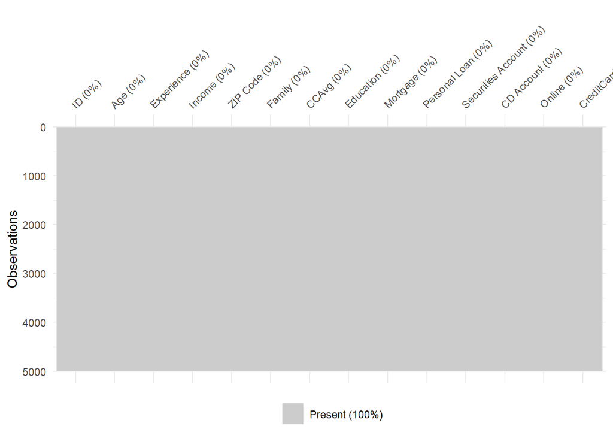

```r
vis_miss(df2, warn_large_data =  FALSE)
```

```r
colnames(df2)[c(10:12)] <- c("Personal.Loan", "Sec.acc","CD.acc")
df2 <- df2[,-c(1,5)] # ignore ID and zip code as recommended by  the book
summary(df2$Mortgage==0) # we check the proportion of clients taking out mortgages
```

```
##    Mode   FALSE    TRUE
## logical    1538    3462
```

This dataset has no missing values, but we have previously encountered the unreasonable minimum value of the variable Experience.

```r
df$Experience[df$Experience <0] <- 20 # replace with the median
summary(df$Experience<0) # checking we have no smaller than 0 values
```

```
##    Mode   FALSE
## logical    5000
```

```r
colnames(df2) # check variable names
```

```
##  [1] "Age"           "Experience"    "Income"        "Family"
##  [5] "CCAvg"         "Education"     "Mortgage"      "Personal.Loan"
##  [9] "Sec.acc"       "CD.acc"        "Online"        "CreditCard"
```

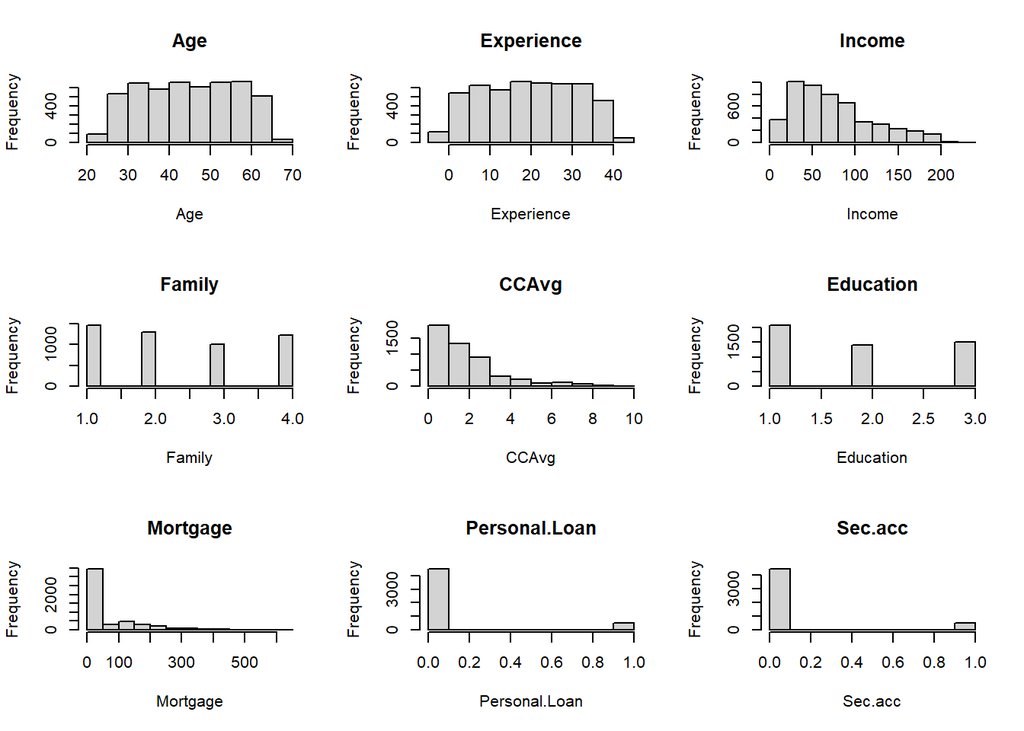

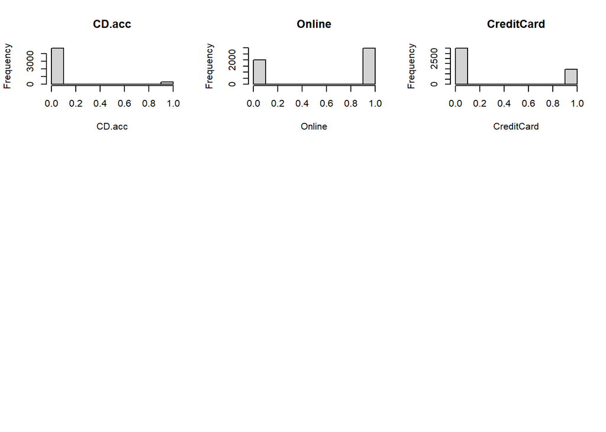

```r
par(mfrow = c(3,3))
for (col in c(1:ncol(df2))) {
  hist(df2[, col],
       main = paste(names(df2[col])),
       xlab = names(df2[col]))
} # plot the densities of all the variables
```

`Experience` is quite spread out, very few individuals seems to have more that 40 years of experience, which is regular given that the average age of the clientele is 45. `Education` is categorical, better to turn it into a dummy. `Personal.Loan` is the variable we want to classify our clients by, whether they respond to the advertisement campaign implemented to increase assets. `Sec.Acc`,`CD.Acc`,`Online`,`Credit Card` all take 1,0 values. The majority seems to use the bank’s online services offers.

```r
df2$Education.1 <- ifelse(df2$Education == 1, 1, 0) # dummy for education=1
df2$Education.2 <- ifelse(df$Education == 2, 1, 0) # dummy for education=2
df2$Education.3 <- ifelse(df2$Education == 3, 1, 0) #dummy for education=3
df2<-as.data.frame(df2[,-c(6,15)]) # get rid of the old education variable and of the 3rd dummy
df2$Personal.Loan <- as.factor(df2$Personal.Loan) # we set it as factor because we want to classify by this variable
```

The logistic regression algorithm would’ve taken care of the education dummy even if we had just left the education variable as factor.

```r
set.seed(1) # to randomly select the records that will make up the samples, and get the same samples when we re-run the code
training<- sample(row.names(df2), 0.6*dim(df2)[1]) # 60% of records makeup the training set
validation <- setdiff(row.names(df2), training ) # 40% the validation set, all records not previously sorted in the training set
train.df<- df2[training,] #in data.frame format
valid.df<- df2[validation,] #in data.frame format
```

We have partitioned the data. We do not normalize the data for the logistic regression, because the logistic regression coefficients express the effect ($beta*100%$) of a unit change in the predictors on the odds. By normalizing the variable would variate from 0 to 1 and the unit change would be from 0 to 1. (https://stats.stackexchange.com/a/124477)(and book pg.240)

Moreover, if we think about standardizing is it coherent to think of `Age`, `Experience`, `Income` with mean values 0 within a regression process.

### 13.1.a

### Logistic Regression

```r
logit.reg<- glm(Personal.Loan ~ ., data = train.df, family = "binomial") # regress on the whole set of predictors
options(scipen = 999) #scientific notation
summary(logit.reg) # recall results
```

```
##
## Call:
## glm(formula = Personal.Loan ~ ., family = "binomial", data = train.df)
##
## Deviance Residuals:
##     Min       1Q   Median       3Q      Max
## -3.0741  -0.1898  -0.0701  -0.0232   4.1048
##
## Coefficients:
##               Estimate Std. Error z value             Pr(>|z|)
## (Intercept) -8.1846978  2.3185999  -3.530             0.000416 ***
## Age         -0.0324946  0.0858273  -0.379             0.704982
## Experience   0.0390812  0.0851023   0.459             0.646072
## Income       0.0591487  0.0038527  15.353 < 0.0000000000000002 ***
## Family       0.5787243  0.0993320   5.826  0.00000000567176278 ***
## CCAvg        0.1548502  0.0571994   2.707             0.006785 **
## Mortgage     0.0011437  0.0007617   1.501             0.133241
## Sec.acc     -0.7739587  0.3957411  -1.956             0.050498 .
## CD.acc       3.7923306  0.4801242   7.899  0.00000000000000282 ***
## Online      -0.6626600  0.2103154  -3.151             0.001628 **
## CreditCard  -1.1142969  0.2877270  -3.873             0.000108 ***
## Education.1 -3.9324934  0.3449324 -11.401 < 0.0000000000000002 ***
## Education.2 -0.1110033  0.2453163  -0.452             0.650916
## ---
## Signif. codes:  0 '***' 0.001 '**' 0.01 '*' 0.05 '.' 0.1 ' ' 1
##
## (Dispersion parameter for binomial family taken to be 1)
##
##     Null deviance: 1838.26  on 2999  degrees of freedom
## Residual deviance:  704.97  on 2987  degrees of freedom
## AIC: 730.97
##
## Number of Fisher Scoring iterations: 8
```

```r
logit.reg.pred<- predict(logit.reg, valid.df[,-7], type="response")
log_pred<-data.frame("Actual Values"=valid.df$Personal.Loan[1:5],"Predictions"=logit.reg.pred[1:5])
kable(log_pred, row.names = T) %>% kable_paper("hover", full_width = T)
```

|  | Actual.Values | Predictions |
| --- | --- | --- |
| 2 | 0 | 0.0000656 |
| 5 | 0 | 0.0060404 |
| 6 | 0 | 0.0045722 |
| 8 | 0 | 0.0003160 |
| 10 | 1 | 0.9750565 |

The first 4 values in the table will be classified as non-acceptors (considering as 0.5 cut-off), the last will be classified as an acceptor. All of these are in line with the Actual values on the left column.

```r
logit_cf<-confusionMatrix(as.factor(ifelse(logit.reg.pred>0.5, 1,0)),valid.df$Personal.Loan, positive = "1")
logit_cf$overall[1]
```

```
## Accuracy
##    0.956
```

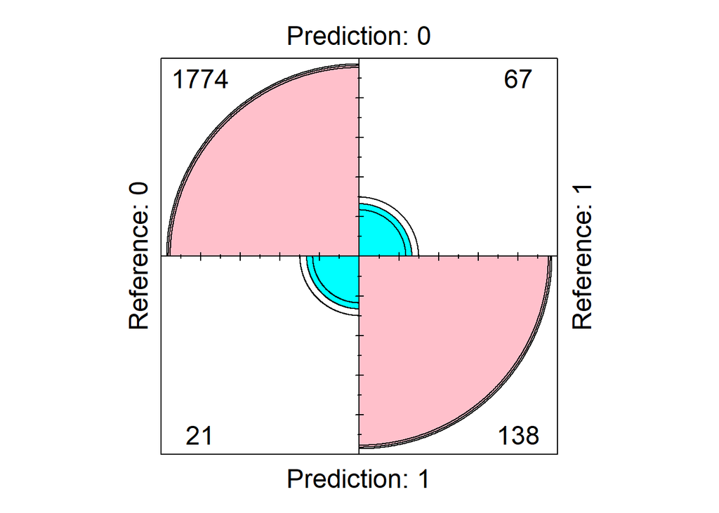

```r
fourfoldplot(logit_cf$table, color = c("cyan", "pink")) # confusion matrix for the logistic regression
```

### KNN

KNN is a distance based classifier, it uses Euclidian distances normalization is needed.

```r
train.norm.df <- train.df #initialize new variables, for the training set
valid.norm.df <- valid.df #for the validation set
normal.values <- preProcess(train.df[, c(1:6)], method=c("range")) # pre-processing, for the needed coefficients from training set
# method range does so that the numerical variables are turned into values within the bounds 0,1
train.norm.df[, c(1:6)] <- predict(normal.values, train.df[, c(1:6)]) # we consider the numerical variables in our data set
valid.norm.df[, c(1:6)]<-  predict(normal.values, valid.df[, c(1:6)]) # we apply the coefficients on validation set
```

```r
knn3<- knn(train.norm.df[, -7], valid.norm.df[, -7], cl = train.norm.df[, 7], k = 3, prob = T) #compute knn on validation data
knn_cf<- confusionMatrix(knn3,valid.norm.df$Personal.Loan, positive = "1") # confusion matrix of the classififcation of validation set
knn_cf$overall[1]
```

```
## Accuracy
##    0.958
```

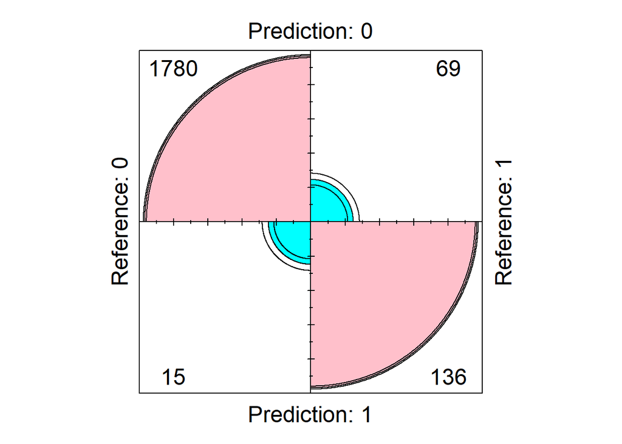

```r
fourfoldplot(knn_cf$table, color = c("cyan", "pink"))
```

### Classification Tree

```r
set.seed(1) #consistent with the seed set for the partitioning
options(scipen = 999)

tree_class <- rpart(Personal.Loan ~ ., data = train.df, method = "class", cp=0.001, minbucket=1, minsplit = 1)
# we do not set a maxdepth, but we set a very low cp, not zero but 0.001

length(tree_class$frame$var[tree_class$frame$var == "<leaf>"]) # how many end nodes
```

```
## [1] 46
```

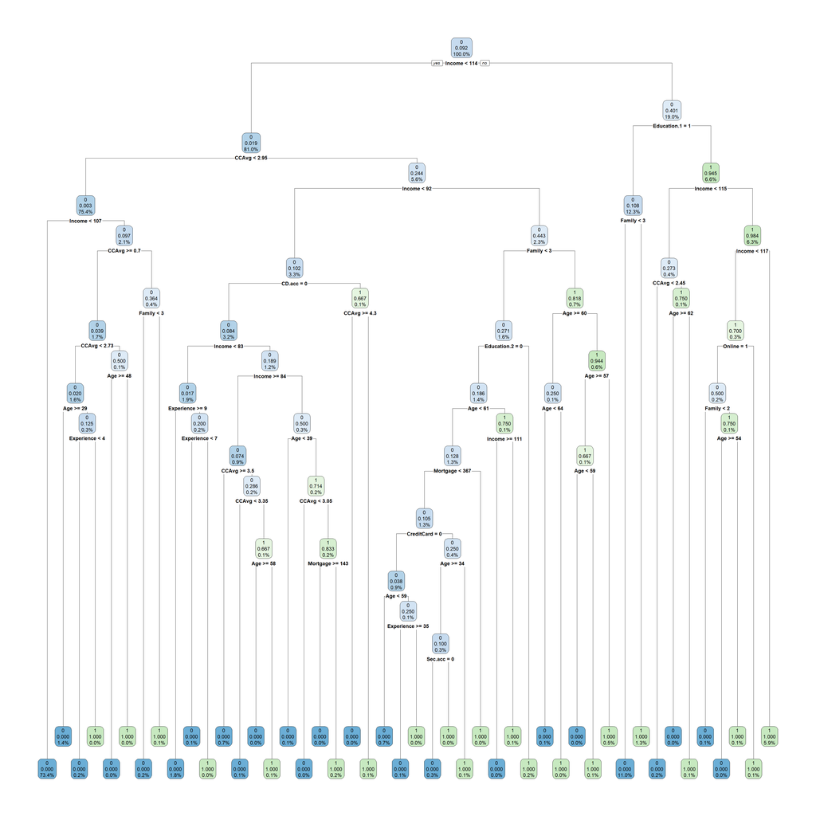

```r
rpart.plot(tree_class, yesno = TRUE, digits =-3) # plot the tree
```

```r
printcp(tree_class)
```

```
##
## Classification tree:
## rpart(formula = Personal.Loan ~ ., data = train.df, method = "class",
##     cp = 0.001, minbucket = 1, minsplit = 1)
##
## Variables actually used in tree construction:
##  [1] Age         CCAvg       CD.acc      CreditCard  Education.1 Education.2
##  [7] Experience  Family      Income      Mortgage    Online      Sec.acc
##
## Root node error: 275/3000 = 0.091667
##
## n= 3000
##
##           CP nsplit rel error  xerror     xstd
## 1  0.3218182      0  1.000000 1.00000 0.057472
## 2  0.1454545      2  0.356364 0.37455 0.036266
## 3  0.0181818      3  0.210909 0.21818 0.027884
## 4  0.0169697      4  0.192727 0.21091 0.027425
## 5  0.0072727      8  0.123636 0.20000 0.026720
## 6  0.0048485     11  0.101818 0.17091 0.024734
## 7  0.0036364     14  0.087273 0.17455 0.024991
## 8  0.0024242     28  0.036364 0.18909 0.025994
## 9  0.0018182     35  0.018182 0.18909 0.025994
## 10 0.0010000     45  0.000000 0.18545 0.025747
```

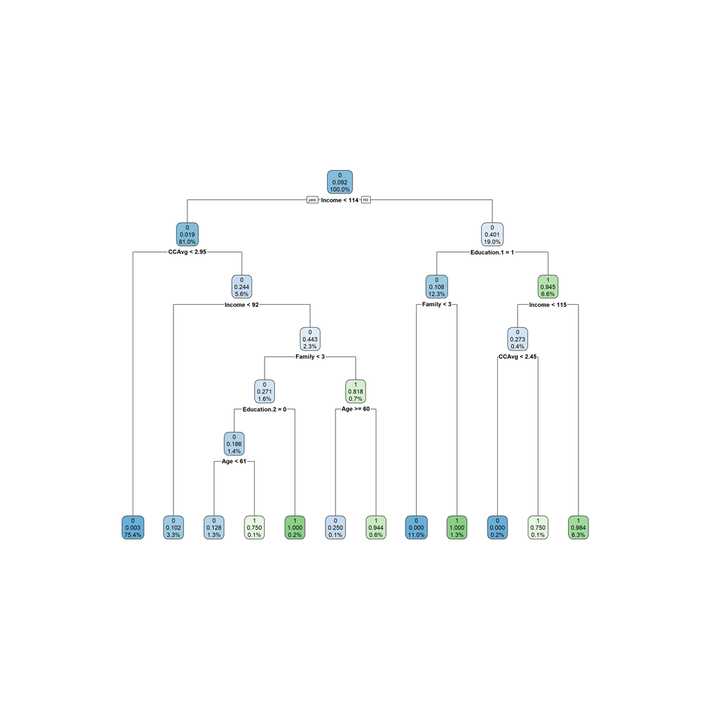

```r
min_xerr<- which.min(tree_class$cptable[,"xerror"]) # select minimum cross-validation error
cp_bp <- tree_class$cptable[min_xerr,"CP"] # find the corresponding CP value, to get teh "best pruned " tree

set.seed(1) # weights are set randomly at the start, make it replicable
pruned_tree<- prune(tree_class, cp = cp_bp) # re-compute the tree with teh selected Cp
rpart.plot(pruned_tree, yesno = TRUE, digits =-3)
```

```r
length(pruned_tree$frame$var[pruned_tree$frame$var == "<leaf>"]) # how many end nodes
```

```
## [1] 12
```

```r
pruned_pred <- predict(pruned_tree, valid.df, type = "class")
```

By pruning the tree we reduce its size from 46 end nodes to 12.

```r
# confusion matrix and accuracy of classification tree
tree_cf<- confusionMatrix(pruned_pred, valid.df$Personal.Loan, positive = "1")
tree_cf$overall[1]
```

```
## Accuracy
##    0.982
```

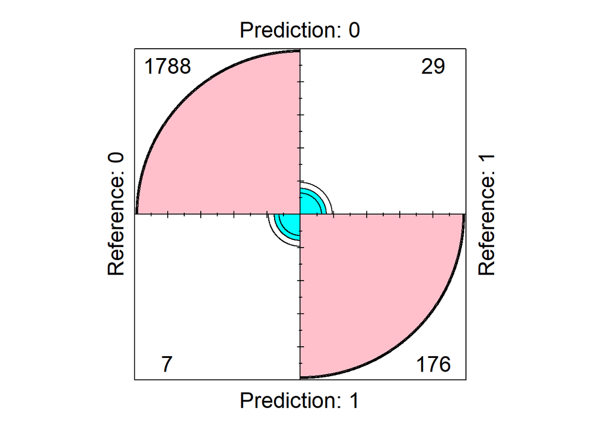

```r
fourfoldplot(tree_cf$table, color = c("cyan", "pink"))
```

We plotted out the accuracy measures ofr the classification tree, we will compare the results later on

### 13.1.b

```r
# build a table withthe predictions
comparison <- data.frame("Actual_values_in_validation"= valid.df$Personal.Loan,
                            "Prediction_from_regression" = logit.reg.pred,
                         "Pred 0,1 From Rregression"= ifelse(logit.reg.pred>0.5, 1,0),
                            "Predictions from knn"= as.numeric(as.character(knn3)),
                            "Predictions from Classification tree"= as.numeric(as.character(pruned_pred)))
first_look<- comparison[c(1:10),] # first 10 predictions
kable(first_look, row.names = T) %>% kable_paper("hover", full_width = T)  # presentation
```

|  | Actual_values_in_validation | Prediction_from_regression | Pred.0.1.From.Rregression | Predictions.from.knn | Predictions.from.Classification.tree |
| --- | --- | --- | --- | --- | --- |
| 2 | 0 | 0.0000656 | 0 | 0 | 0 |
| 5 | 0 | 0.0060404 | 0 | 0 | 0 |
| 6 | 0 | 0.0045722 | 0 | 0 | 0 |
| 8 | 0 | 0.0003160 | 0 | 0 | 0 |
| 10 | 1 | 0.9750565 | 1 | 1 | 1 |
| 12 | 0 | 0.0050068 | 0 | 0 | 0 |
| 13 | 0 | 0.2440329 | 0 | 0 | 1 |
| 19 | 1 | 0.9930958 | 1 | 1 | 1 |
| 20 | 0 | 0.0001261 | 0 | 0 | 0 |
| 21 | 0 | 0.0040434 | 0 | 0 | 0 |

So we have built a table with the predictions that the three different models produced. For the regression output we use a 0.5 threshold by which we classify the probabilities.

### 13.1.c

To apply the average and the majority rule to 3 elements within the bounds [0,1], would yield the same results more or less. We would be ignoring information that can be derived from our models.

So we extrapolate the classification probabilities for each of the models we used (we already have the one for the logistic regression), and compute the average with those. An average that we will then filter with a 0.5 cut-off. Finally, use the majority vote method on the 0,1s.

`prob_knn` is the probability of an element being classified as whatever the knn process classified it as. So we need to re-elaborate these values, when the K-nearest neighbour classifies the element i as belonging to the class of interest (1), we leave the probability as it is. If the element is classified as non-respondant, then we need to substitute the probability `prob_knn` with 1-`prob_knn`.

```r
comparison$prob_knn<-attr(knn3, "prob")
for(i in 1:NROW(comparison)){
  new_prob <- if(comparison[i,"Predictions.from.knn"]==1) comparison[i,"prob_knn"] else 1 - comparison[i,"prob_knn"]
  comparison[i,"prob_knn"] <- new_prob
}
 # for loop, iterating over every row in the table comparison
 # if the knn predicts for the element i to be in teh responsive class, we leave the porbability as it is
 # if it is under the 0 class, we adjust the probability values
 # substitute the values with the new probabilities
```

We then get the probabilities for the classification tree, which come in the form of two columns 0,1 our class of interest is 1 of course, we add it to the table.

```r
prob_tree<- predict(pruned_tree, valid.df, type = "prob") # probabilities out of the pruned tree
comparison$tree_prob<- prob_tree[,2] # select the ones regarding the class 1

comparison$average <- apply(comparison[,c(2,6,7)],FUN = mean, MARGIN = 1) # new column with average of probabilities
comparison$avg_round<- round(comparison[,8])                              # we round the results to 0,1
comparison$majority<- apply(comparison[,c(3,4,5)],FUN = mfv, MARGIN = 1)  # majority vote over the 3 methods predictions
```

### Confusion matrix on the two methods:

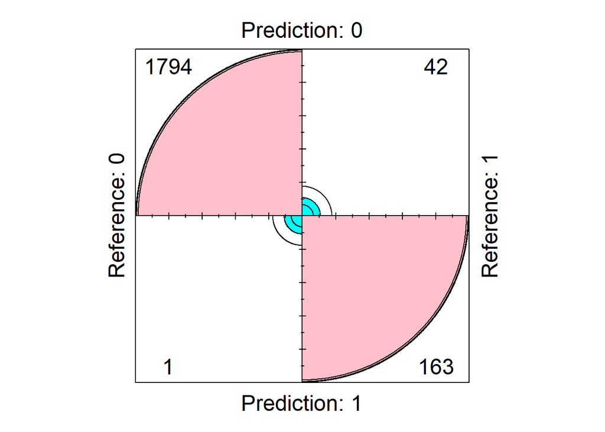

```r
options(scipen =999)
avg_cf<- confusionMatrix(as.factor(comparison$avg_round),valid.df$Personal.Loan, positive = "1") # for average
maj_cf<- confusionMatrix(as.factor(comparison$majority),valid.df$Personal.Loan, positive="1")    # for majority vote

fourfoldplot(avg_cf$table, color = c("cyan", "pink")) #confusion matrix presentation
```

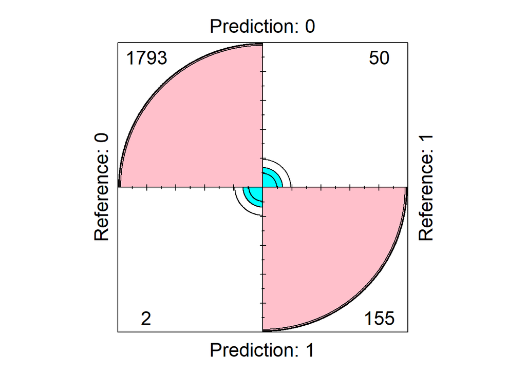

```r
fourfoldplot(maj_cf$table, color= c("cyan", "pink"))
```

```r
avg_cf$overall[1] # accuracy rates
```

```
## Accuracy
##   0.9785
```

```r
maj_cf$overall[1]
```

```
## Accuracy
##    0.974
```

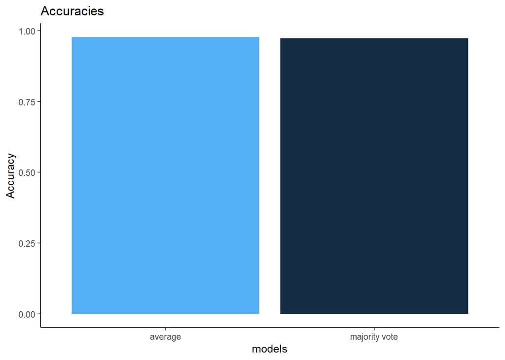

```r
# plot the rates
models<- data.frame("models"=c("average", "majority vote"), "Accuracy"= c(avg_cf$overall[1], maj_cf$overall[1]))
ggplot(models) + geom_col(aes(x=models,y= Accuracy, fill=Accuracy), show.legend = F)+ theme_classic()+ ggtitle("Accuracies")
```

The 2 methods seem to perform very closely to one another. Average is slightly higher in terms of Accuracy, this is probably due to the fact that averaging used probabilities, which captured more information,rather than a simple majority vote over 3 0,1 outcomes. Given that we are analysing a datset where our positive class is a minority we could higher cut-off value for classification.

### Error rates of all models

### 13.1.d

The classification error rates are 1- accuracy measures:

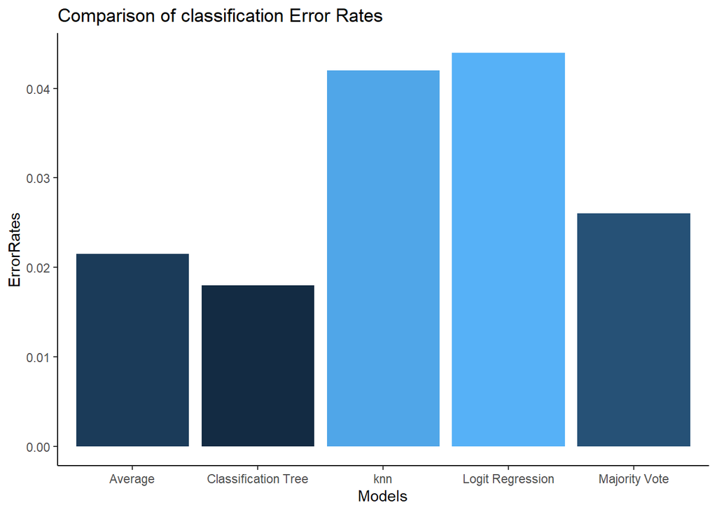

```r
ErrorRates<-c(1 - avg_cf$overall[1], 1- maj_cf$overall[1],  1- logit_cf$overall[1],  1- knn_cf$overall[1],  1- tree_cf$overall[1])

err_rates<- data.frame("Models"= c("Average", "Majority Vote", "Logit Regression", "knn", "Classification Tree"), "ErrorRates"= ErrorRates)
ggplot(err_rates) + geom_col(aes(x=Models,y= ErrorRates, fill=ErrorRates), show.legend = F)+ theme_classic()+ ggtitle("Comparison of classification Error Rates")
```

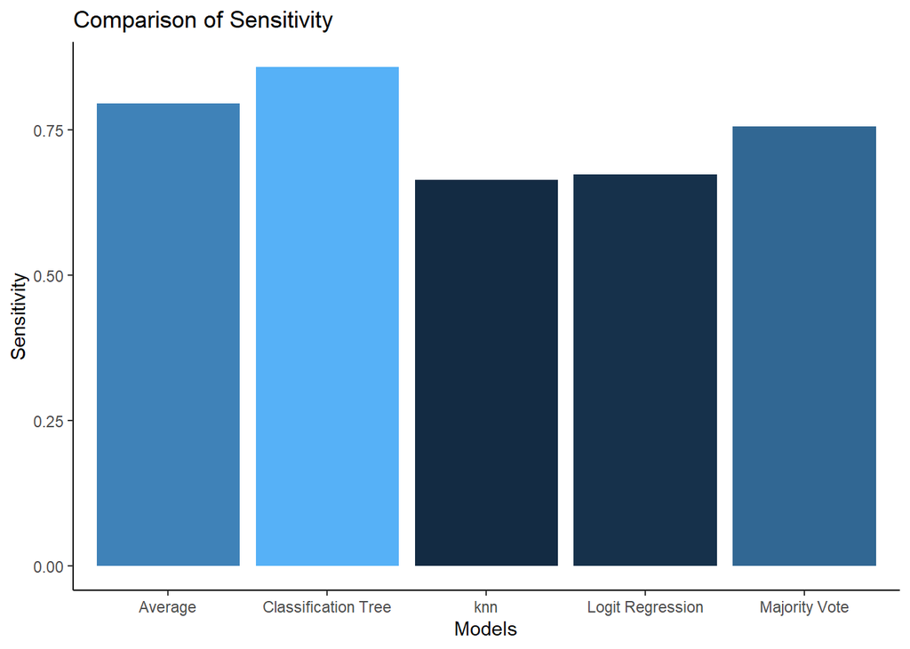

```r
# we plot sensitivty and Specificity as well
Sensitivity<- c(avg_cf$byClass[1],maj_cf$byClass[1], logit_cf$byClass[1], knn_cf$byClass[1], tree_cf$byClass[1])
Specificity<- c(avg_cf$byClass[2],maj_cf$byClass[2], logit_cf$byClass[2], knn_cf$byClass[2], tree_cf$byClass[2])


Sensitivity_df<- data.frame("Models"= c("Average", "Majority Vote", "Logit Regression", "knn", "Classification Tree"), "Sensitivity"= Sensitivity)
ggplot(Sensitivity_df) + geom_col(aes(x=Models,y= Sensitivity, fill=Sensitivity), show.legend = F)+ theme_classic()+ ggtitle("Comparison of Sensitivity")
```

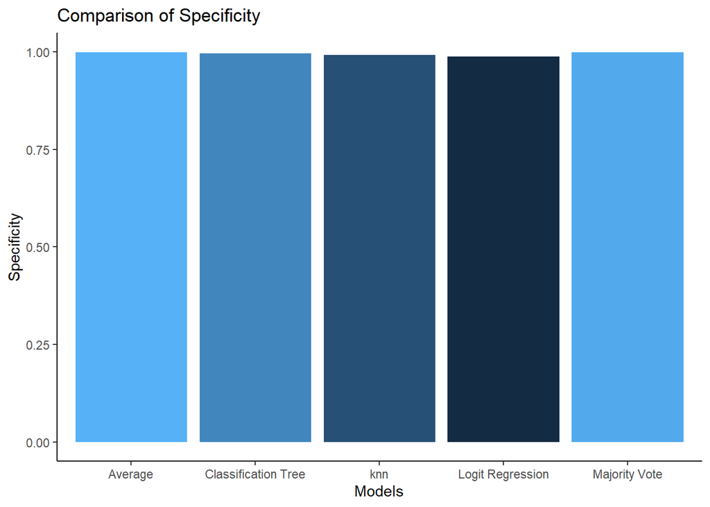

```r
Specificity_df<- data.frame("Models"= c("Average", "Majority Vote", "Logit Regression", "knn", "Classification Tree"), "Specificity"= Specificity)
ggplot(Specificity_df) + geom_col(aes(x=Models,y= Specificity, fill=Specificity), show.legend = F)+ theme_classic()+ ggtitle("Comparison of Specificity")
```

At first look they seem very different but they actually are quite close to one another, it seems like the classification tree does a better job than any other model in this case. Majority vote is the 3rd worse classificator, this could attributed to the use of 0,1 values, which sacrifices some information. Logistic regression could be improved with variable selection, and knn with finding the optimal k value.